# KL-Optimality: designs for model discrimination

```r
library(optedr)
```

## Background

Standard optimality criteria (D, A, I, …) assume the model is correctly specified and aim to estimate its parameters as precisely as possible. KL-Optimality addresses a different question: *given two competing models, where should observations be taken to tell them apart most easily?*

The criterion is based on the Kullback-Leibler divergence between the reference model $f_1$ and the best-fitting version of the rival $f_2$:

$$\Phi_{\text{KL}}(\xi) = \int
\min_{\beta_2} \text{KL}(f_1(y \mid x) \,\|\, f_2(y \mid x, \beta_2))\,
\xi(dx).$$

The design $\xi^*$ that maximises $\Phi_{\text{KL}}$ places observations where the two models are most distinguishable on average.

**Reference:** López-Fidalgo, Tommasi & Trandafir (2007). *An optimal experimental design criterion for discriminating between non-normal models.* J. R. Stat. Soc. B, 69(2), 231–242.

## API overview

```r
opt_des(
  "KL-Optimality",
  model        = <reference model formula>,
  parameters   = <reference parameter names>,
  par_values   = <nominal values>,
  design_space = <scalar interval or named list>,
  # rival specification:
  rival_model  = <rival formula>,       # default: same as model
  rival_params = <rival param names>,   # default: same as parameters
  rival_pars   = <starting values for internal optimisation>,
  rival_lower  = <lower bounds for rival params>,
  rival_upper  = <upper bounds for rival params>,
  # GLM family:
  family       = "Normal",   # "Poisson", "Binomial", "Gamma"
  phi          = 1,          # dispersion parameter
  # alternative: supply a custom KL function
  kl_fun       = NULL
)
```

The internal optimisation over rival parameters is done automatically. The optimal rival values are stored as a hidden attribute and shown by `summary()`.

## Example 1: Michaelis-Menten vs linear rival (Normal, 1D)

**Context.** Enzyme kinetics with one substrate. The reference model is Michaelis-Menten $\mu(x) = V_{\max} x / (K_m + x)$ with $V_{\max} = 2$, $K_m = 1$. The rival is a linear rate $\mu(x) = a x$, valid only when $x \ll K_m$. At high concentrations MM saturates while the linear model keeps growing — that is where the models diverge most.

```r
result_kl_mm <- opt_des(
  "KL-Optimality",
  model        = y ~ Vmax * x / (Km + x),
  parameters   = c("Vmax", "Km"),
  par_values   = c(2, 1),
  design_space = c(0.1, 5),
  rival_model  = y ~ a * x,
  rival_params = c("a"),
  rival_pars   = c(1),
  rival_lower  = c(0.2),
  rival_upper  = c(2.5),
  family       = "Normal",
  phi          = 1
)
```

```
#>
#> ℹ Stop condition reached: difference between sensitivity and criterion < 1e-05
#> ⠙ Calculating optimal design 7 done (5/s) | 1.4sℹ The lower bound for efficiency is 99.9957589718079%
#>
```

```r
result_kl_mm
```

```
#> Optimal design for KL-Optimality:
#>      Point    Weight
#> 1 1.127578 0.8159831
#> 2 5.000000 0.1840169
```

`summary()` shows the GLM family and the optimal rival parameters found by the internal optimisation:

```r
summary(result_kl_mm)
```

```
#> Model:
#> y ~ Vmax * x/(Km + x)
#> Weight function:
#> function (x)
#> 1
#>
#> GLM family: Normal  (phi = 1)
#> Optimal rival parameters: 0.445
#>
#> Optimal design for KL-Optimality:
#>      Point    Weight
#> 1 1.127578 0.8159831
#> 2 5.000000 0.1840169
#>
#> Minimum efficiency (Atwood): 99.9957589718079%
#> Criterion value:             0.155804
```

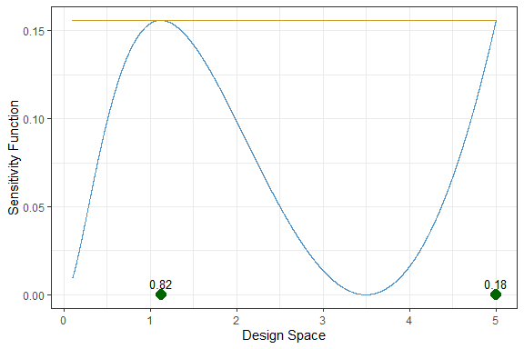

KL sensitivity function: MM vs linear rival.

```r
plot(result_kl_mm)
```

Efficiency of a five-point uniform design relative to the KL-optimal:

```r
design_unif <- data.frame(
  Point  = c(0.1, 1.3, 2.5, 3.8, 5.0),
  Weight = rep(1/5, 5)
)
eff_kl <- design_efficiency(design_unif, result_kl_mm)
```

```
#> ℹ The efficiency of the design is 44.1071528869909%
```

```r
cat("Efficiency of uniform design:", round(eff_kl * 100, 2), "%\n")
```

```
#> Efficiency of uniform design: 44.11 %
```

## Example 2: exponential decay, Poisson family

**Context.** A drug clearance study where the event count follows a Poisson process with rate $\mu(x) = \exp(a - bx)$. The reference model has nominal decay rate $b = 0.5$. The rival represents a faster-elimination regime ($b \in [0.8, 1.5]$), which could arise from drug interactions. The KL divergence for Poisson is $\text{KL} = \mu_2 - \mu_1 - \mu_1 \log(\mu_2/\mu_1)$; since the rival decays faster, the gap is largest at long follow-up times.

```r
result_kl_pois <- opt_des(
  "KL-Optimality",
  model        = y ~ exp(a - b * x),
  parameters   = c("a", "b"),
  par_values   = c(2, 0.5),
  design_space = c(0, 4),
  rival_pars   = c(2, 1.0),
  rival_lower  = c(1.5, 0.8),
  rival_upper  = c(2.5, 1.5),
  family       = "Poisson",
  phi          = 1
)
```

```
#>
#> ℹ Stop condition reached: difference between sensitivity and criterion < 1e-05
#> ⠙ Calculating optimal design 4 done (5.2/s) | 768msℹ The lower bound for efficiency is 99.9999938849073%
#>
```

```r
result_kl_pois
```

```
#> Optimal design for KL-Optimality:
#>   Point    Weight
#> 1     0 0.2012678
#> 2     4 0.7987322
```

```r
summary(result_kl_pois)
```

```
#> Model:
#> y ~ exp(a - b * x)
#> Weight function:
#> function (x)
#> 1
#>
#> GLM family: Poisson  (phi = 1)
#> Optimal rival parameters: 2.2799, 0.8
#>
#> Optimal design for KL-Optimality:
#>   Point    Weight
#> 1     0 0.2012678
#> 2     4 0.7987322
#>
#> Minimum efficiency (Atwood): 99.9999938849073%
#> Criterion value:             0.318553
```

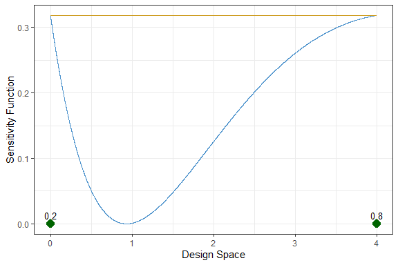

KL sensitivity for Poisson decay model.

```r
plot(result_kl_pois)
```

The optimal rival parameters found internally confirm the closest rival within the constraint:

```r
hv <- attr(result_kl_pois, "hidden_value")
cat("Optimal rival: a =", round(hv$beta2_star[1], 3),
    " b =", round(hv$beta2_star[2], 3), "\n")
```

```
#> Optimal rival: a = 2.28  b = 0.8
```

## Using `make_kl_fun()` for custom KL functions

For some discrimination problems the KL divergence does not reduce to the standard cumulant-generating-function form that `opt_des()` uses internally. `make_kl_fun()` automates the construction of the KL function from two model-family pairs.

### Supported pairs

| Combination | Formula |
| --- | --- |
| Same family, same $\phi$ | Standard cumulant form |
| Normal vs Normal, $\phi_1 \neq \phi_2$ | $\frac{1}{2}\left[\log\frac{\phi_2}{\phi_1} + \frac{\phi_1}{\phi_2} + \frac{(\mu_1-\mu_2)^2}{\phi_2} - 1\right]$ |
| Gamma vs Gamma, different shape | Closed form with digamma/lgamma |

For other pairs, supply `kl_fun` directly as a function `(x, beta2) -> scalar`.

### Example 3: Normal with different variances (1D)

**Context.** Same exponential decay model, but now the rival has variance $\phi_2 = 4$ (four times larger). The KL function includes a constant term $\frac{1}{2}[\log(\phi_2/\phi_1) + \phi_1/\phi_2 - 1]$ even when the means coincide, so the design must also account for the variance difference.

```r
kl_fn_var <- make_kl_fun(
  "Normal",
  model1      = y ~ a * exp(-b * x),
  params1     = c("a", "b"),
  par_values1 = c(1, 0.5),
  phi1        = 1,
  family2     = "Normal",
  model2      = y ~ c * exp(-d * x),
  params2     = c("c", "d"),
  phi2        = 4
)

result_kl_var <- opt_des(
  "KL-Optimality",
  model        = y ~ a * exp(-b * x),
  parameters   = c("a", "b"),
  par_values   = c(1, 0.5),
  design_space = c(0, 4),
  kl_fun       = kl_fn_var,
  rival_pars   = c(1, 1.0),
  rival_lower  = c(0.5, 0.8),
  rival_upper  = c(2.0, 1.5)
)
```

[output not shown]

```r
result_kl_var
```

```
#> Optimal design for KL-Optimality:
#>      Point     Weight
#> 1 0.000000 0.16826906
#> 2 1.333333 0.07912872
#> 3 1.989481 0.61240029
#> 4 2.666667 0.14020193
```

```r
summary(result_kl_var)
```

```
#> Model:
#> y ~ a * exp(-b * x)
#> Weight function:
#> function (x)
#> 1
#>
#> KL function: user-supplied
#> Optimal rival parameters: 1.1353, 0.8
#>
#> Optimal design for KL-Optimality:
#>      Point     Weight
#> 1 0.000000 0.16826906
#> 2 1.333333 0.07912872
#> 3 1.989481 0.61240029
#> 4 2.666667 0.14020193
#>
#> Minimum efficiency (Atwood): 99.9671378206639%
#> Criterion value:             0.320445
```

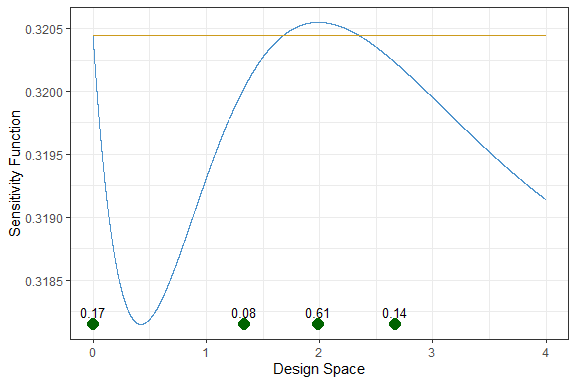

KL sensitivity: Normal phi=1 vs Normal phi=4.

```r
plot(result_kl_var)
```

### Example 4: two-factor MM vs linear rival (`make_kl_fun`, 2D)

`make_kl_fun()` works with models that use different subsets of the design variables. Here the reference uses $(x_1, x_2)$ (bisubstrate MM) while the rival depends only on $x_1$ (single-substrate linear approximation):

```r
kl_fn_2d <- make_kl_fun(
  "Normal",
  model1      = y ~ Vmax * x1 * x2 / ((Km1 + x1) * (Km2 + x2)),
  params1     = c("Vmax", "Km1", "Km2"),
  par_values1 = c(1, 1, 1),
  model2      = y ~ alpha * x1,
  params2     = "alpha"
)

result_kl_2d <- opt_des(
  "KL-Optimality",
  model        = y ~ Vmax * x1 * x2 / ((Km1 + x1) * (Km2 + x2)),
  parameters   = c("Vmax", "Km1", "Km2"),
  par_values   = c(1, 1, 1),
  design_space = list(x1 = c(0.1, 5), x2 = c(0.1, 5)),
  kl_fun       = kl_fn_2d,
  rival_pars   = c(0.5),
  rival_lower  = c(0.05),
  rival_upper  = c(2.0)
)
```

```
#>
#> ℹ Stop condition reached: difference between sensitivity and criterion < 1e-05
#> ⠙ Calculating optimal design 9 done (5.4/s) | 1.7sℹ The lower bound for efficiency is 99.9887728054157%
#>
```

```r
result_kl_2d
```

```
#> Optimal design for KL-Optimality (2 factors):
#>         x1       x2    Weight
#> 1 2.048054 4.998983 0.7094157
#> 2 5.000000 0.100000 0.2905843
```

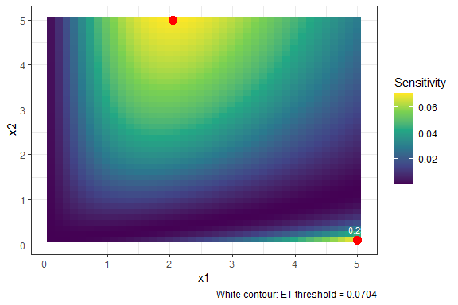

KL sensitivity heatmap: 2D MM vs linear rival.

```r
plot(result_kl_2d)
```

## Example 5: discriminating error structures — the Hill model

**Reference:** De la Calle-Arroyo, Leorato, Rodríguez-Aragón & Tommasi (2025). *Augmented designs to choose between constant absolute and relative errors.* Chemometrics and Intelligent Laboratory Systems, doi:10.1016/j.chemolab.2025.105374.

**Context.** Dose-response experiments with the Hill (4-parameter Emax) model:

$$\eta(x, \beta) = (E_{\text{con}} - b)
\cdot \frac{(x/\text{IC}_{50})^s}{1 + (x/\text{IC}_{50})^s} +
b$$

with $E_{\text{con}} = 1.70$, $b = 0.137$, $\text{IC}_{50} = 111$, $s = -1.03$ and $x \in [0.01, 1500]$ nM. Two error structures are competing:

- **Relative error** (reference): $\varepsilon \sim N(0,\, \sigma_{\text{rel}}^2 \cdot \eta^2)$
- **Absolute error** (rival): $\varepsilon \sim N(0,\, \sigma_{\text{abs}}^2)$

The KL divergence minimised over the rival variance $\sigma_{\text{abs}}^2$ is

$$\text{KL}(x,\, \sigma_{\text{abs}}^2) =
\frac{1}{2}\!\left(\frac{\eta^2(x)}{\sigma_{\text{abs}}^2} - 1 +
\log\frac{\sigma_{\text{abs}}^2}{\eta^2(x)}\right).$$

We supply this directly as `kl_fun` since it is not covered by the standard Normal-vs-Normal formula (the reference variance is $x$-dependent):

```r
kl_fun_hill <- function(x, beta2) {
  sigma_sq <- beta2[1]
  eta <- (1.70 - 0.137) * (x / 111)^(-1.03) / (1 + (x / 111)^(-1.03)) + 0.137
  0.5 * (eta^2 / sigma_sq - 1 + log(sigma_sq / eta^2))
}

result_kl_hill <- opt_des(
  "KL-Optimality",
  model        = y ~ (Econ - b) * (x / IC50)^s / (1 + (x / IC50)^s) + b,
  parameters   = c("Econ", "b", "IC50", "s"),
  par_values   = c(1.70, 0.137, 111, -1.03),
  design_space = c(0.01, 1500),
  kl_fun       = kl_fun_hill,
  rival_pars   = c(1.0),
  rival_lower  = c(1e-4),
  rival_upper  = c(1e6)
)
```

```
#>
#> ℹ Stop condition reached: difference between sensitivity and criterion < 1e-05
#> ⠙ Calculating optimal design 5 done (21/s) | 238msℹ The lower bound for efficiency is 99.9997190548208%
#>
```

```r
result_kl_hill
```

```
#> Optimal design for KL-Optimality:
#>     Point   Weight
#> 1    0.01 0.233994
#> 2 1500.00 0.766006
```

```r
summary(result_kl_hill)
```

```
#> Model:
#> y ~ (Econ - b) * (x/IC50)^s/(1 + (x/IC50)^s) + b
#> Weight function:
#> function (x)
#> 1
#>
#> KL function: user-supplied
#> Optimal rival parameters: 0.7192
#>
#> Optimal design for KL-Optimality:
#>     Point   Weight
#> 1    0.01 0.233994
#> 2 1500.00 0.766006
#>
#> Minimum efficiency (Atwood): 99.9997190548208%
#> Criterion value:             0.813492
```

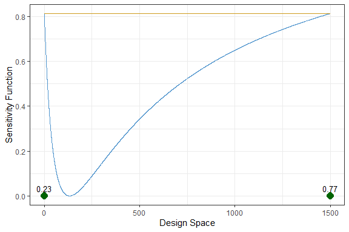

KL sensitivity for the Hill model (error structure discrimination).

```r
plot(result_kl_hill)
```

The KL-optimal design places all weight at the two extremes of the design space. This matches the result reported in the paper (support at $x = 0.01$ with weight 0.23 and $x = 1500$ with weight 0.77). The Atwood criterion at 100 % confirms the design is exactly optimal.

The optimal rival variance recovered internally:

```r
hv_hill <- attr(result_kl_hill, "hidden_value")
cat("Optimal rival sigma_abs^2 =", round(hv_hill$beta2_star, 4), "\n")
```

```
#> Optimal rival sigma_abs^2 = 0.7192
```

Note that with only two support points this design cannot estimate all four parameters of the Hill model. The paper proposes combining it with a D-optimal design via the augmentation workflow described in `vignette("optedr-augment")`.